# Exploring the BRFSS data

## Setup

### Load packages

```r
library(ggplot2)
library(dplyr)
library(tidyr)
```

### Load data

```r
load("brfss2013.RData")
```

## Part 1: Data

The data comes from the Behavioral Risk Factor Surveillance System (BRFSS), an observational study conducted in all 50 states in the US and participating US territories. The population of interest are non-institutionalized adults aged 18+ living in the United States or participating territories.

Data is collected by surveying randomly selected adults from households contacted via a landline; or, cellular phone users that reside in a private residence or student housing at a college or university. This study is observational, and therefore no causal relationships can be inferred from this data. In addition, the sample population is limited a bit to the subset of the stated population that have either a landline or celular phone.

There are many potential problems with the data collection. Certain population segments may be less likely to answer their phone, or may be at home less and therefore unable to be sampled. In addition, the proportion of samples from each state is not in line with the proportion of the the total US population for each state. Therefore certain states and / or regions may be over or under sampled within the data.

## Part 2: Research questions

I’m interested in how the dominant political view within states associates with the health and frequency of routine health care of the state’s military veterans. States will be typed into two classes - red or blue. Red states will be defined as states that Mitt Romney carried in the 2012 presidential election, and blue states will be those carried by Barak Obama. Since Guam and Puerto Rico do not vote in the presidential election, I will exclude them from my analysis.

I will first look at how general health between veterans and non-veterans differ by state type. Second, I will look at how frequency of routine health care varies between veterans and non-veterans by state type.

Members of the US military have been encouraged to smoke tobacco. Cigarettes were part of K anc C ration kits throughout the 2nd world war [http://tobaccocontrol.bmj.com/content/7/3/219]. My third question will look at the association of respondents who have been diagnosed with a heart attack with smokers and non-smokers among veterans and non-veterans.

**Research quesion 1:**

For respondents reporting on their general health, are there assocations between veteran status or the political leaning of the respondent’s state in the reported quality of health?

**Research quesion 2:**

Is there an association between veteran status or the political leaning of the respondent’s state in the frequency of routine health care?

**Research quesion 3:**

Are being a veteran and smoking more than 100 cigarettes associated with being diagnosed with a heart attack?

## Part 3: Exploratory data analysis

First, I will create a new data frame with only the features I’ll need for my analysis. I’ll also get rid of any rows with N/A values.

```r
# select columns I want for my questions

# State column 1
# Veteran column 45
# Time since checkup 26
# General Health 19
# Smoker 68
# Heart Attack 33

# list of columns I want

list<-c(1,19,26,33,45,68)

# create new dataframe with only the columns I want

mydata<-brfss2013[,list]

# Use complete.cases to get rid of N/As

completes<-complete.cases(mydata)

mydata<-mydata[completes,]

# dimensions of data frame with N/A removed

dim(mydata)
```

```
## [1] 466472      6
```

I have 466,472 observaions of 6 features. I now need to classify each state as either red or blue and add that into my dataframe. This data is from 2013, so I will use the results of the 2012 presidential election to classify the states. Red states will be those that went to Mitt Romney and blue state will be those that went to Barak Obama.

```r
# pull out states to classify as red or blue

states<-mydata %>%
  group_by(X_state) %>%
  summarize()

# write out states to append "Blue" or "Red" status
# write.csv(states, "matchstates.csv")

# Read in state data with state Type added:

statejoin<-read.csv("matchstates.csv")

# Convert X_state to character to facilitate join

mydata$X_state<-as.character(mydata$X_state)

statejoin$X_state<-as.character(statejoin$X_state)

# Use inner join to add "Type" column to mydata

mydata<-inner_join(mydata, statejoin)
# convert factors to numeric

mydata$genhlth<-as.numeric(mydata$genhlth)

mydata$checkup1<-as.numeric(mydata$checkup1)

# quick peek at table

head(mydata)
```

```
##   X_state genhlth checkup1 cvdinfr4 veteran3 smoke100 Type
## 1 Alabama       4        1       No       No      Yes  Red
## 2 Alabama       3        1       No       No       No  Red
## 3 Alabama       3        1       No       No      Yes  Red
## 4 Alabama       2        2       No       No       No  Red
## 5 Alabama       3        4       No       No      Yes  Red
## 6 Alabama       2        1       No       No       No  Red
```

Now that I’ve got the data set together, I’ll move on to the research questions.

**Research quesion 1:**

For respondents reporting on their general health, are there assocations between veteran status or the political leaning of the respondent’s state in the reported quality of health?

I’ll first select the features of interest for this questions and look at some summary statistics:

```r
# Select data to work on question 1

sum1<- mydata %>%
  select(genhlth, veteran3, Type) %>%
  group_by(Type, veteran3) %>%
  summarise(Q1=quantile(genhlth, .25), Mean=mean(genhlth), Median=median(genhlth),
            Q3=quantile(genhlth, .75), IQR=IQR(genhlth), StDev=sd(genhlth)) %>%
  mutate(Skew=ifelse(Mean>Median, "Right", "Left"))

head(sum1)
```

```
## # A tibble: 4 x 9
## # Groups:   Type [2]
##     Type veteran3    Q1     Mean Median    Q3   IQR    StDev  Skew
##   <fctr>   <fctr> <dbl>    <dbl>  <dbl> <dbl> <dbl>    <dbl> <chr>
## 1   Blue      Yes     2 2.624451      3     3     1 1.095619  Left
## 2   Blue       No     2 2.495723      2     3     1 1.079831 Right
## 3    Red      Yes     2 2.721397      3     3     1 1.110370  Left
## 4    Red       No     2 2.612808      3     3     1 1.101839  Left
```

The histograms below show how the data is distributed for all four groups:

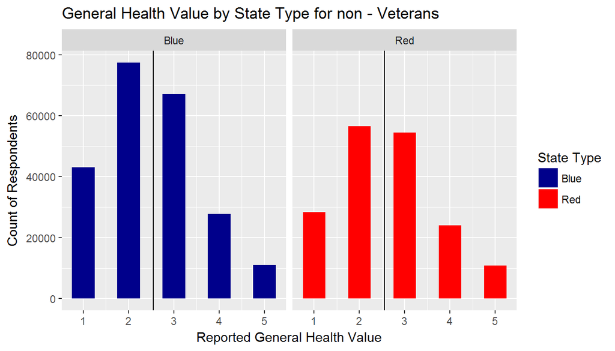

```r
# Non Veteran histogram data

p1dat<-mydata %>%
  select(genhlth, veteran3, Type) %>%
  filter(veteran3=="No")

# Veteran histogram data

p2dat<-mydata %>%
  select(genhlth, veteran3, Type) %>%
  filter(veteran3=="Yes")

# Histogram of non-Veterans

p1<-ggplot(p1dat, aes(genhlth, fill=Type))+geom_histogram(binwidth = .5)+
  facet_grid(.~Type)+scale_fill_manual(values=c("#00008b", "#ff0000"))+
  geom_vline(xintercept=mean(p1dat$genhlth), color="black")+
  ggtitle("General Health Value by State Type for non - Veterans")+
  guides(fill=guide_legend(title="State Type"))+
  ylab("Count of Respondents") + xlab("Reported General Health Value")

p1
```

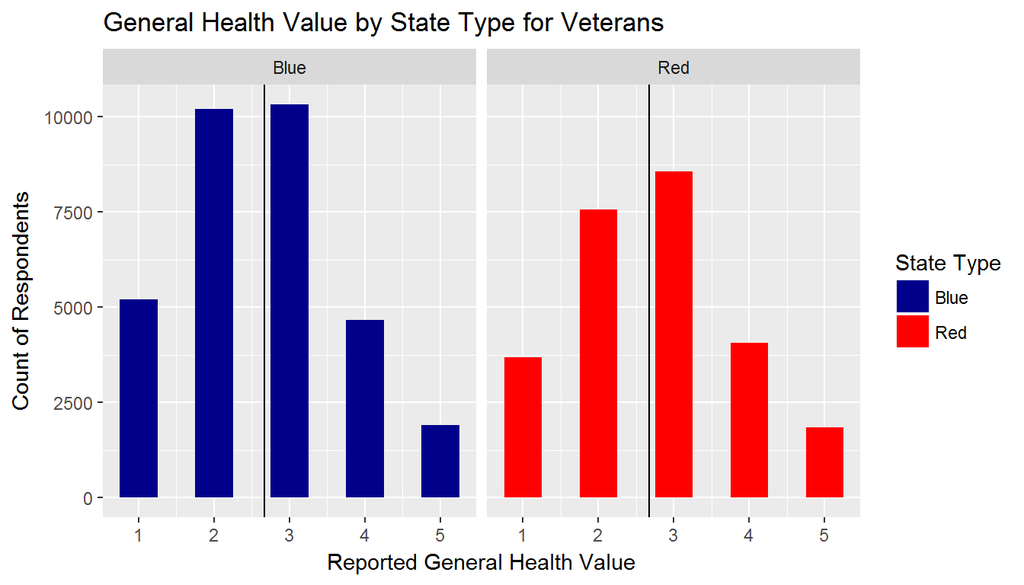

```r
# Histogram of veterans

p2<-ggplot(p2dat, aes(genhlth, fill=Type))+geom_histogram(binwidth = .5)+
  facet_grid(.~Type)+scale_fill_manual(values=c("#00008b", "#ff0000"))+
  geom_vline(xintercept = mean(p2dat$genhlth), color="black")+
  ggtitle("General Health Value by State Type for Veterans")+
  guides(fill=guide_legend(title="State Type"))+
  ylab("Count of Respondents") + xlab("Reported General Health Value")

p2
```

**Research quesion 2:**

Is there an association between veteran status or the political leaning of the respondent’s state in the frequency of routine health care?

Again, I’ll organize the data required and look at the summary statistics:

```r
sum2<- mydata %>%
  select(checkup1, veteran3, Type) %>%
  group_by(Type, veteran3) %>%
  summarise(Q1=quantile(checkup1, .25), Mean=mean(checkup1), Median=median(checkup1),
            Q3=quantile(checkup1, .75), IQR=IQR(checkup1), StDev=sd(checkup1)) %>%
  mutate(Skew=ifelse(Mean>Median, "Right", "Left"))

head(sum2)
```

```
## # A tibble: 4 x 9
## # Groups:   Type [2]
##     Type veteran3    Q1     Mean Median    Q3   IQR     StDev  Skew
##   <fctr>   <fctr> <dbl>    <dbl>  <dbl> <dbl> <dbl>     <dbl> <chr>
## 1   Blue      Yes     1 1.322532      1     1     0 0.7831108 Right
## 2   Blue       No     1 1.492564      1     2     1 0.9349688 Right
## 3    Red      Yes     1 1.384499      1     1     0 0.8659965 Right
## 4    Red       No     1 1.572493      1     2     1 1.0234957 Right
```

These histograms show the distribution for each of the four groups:

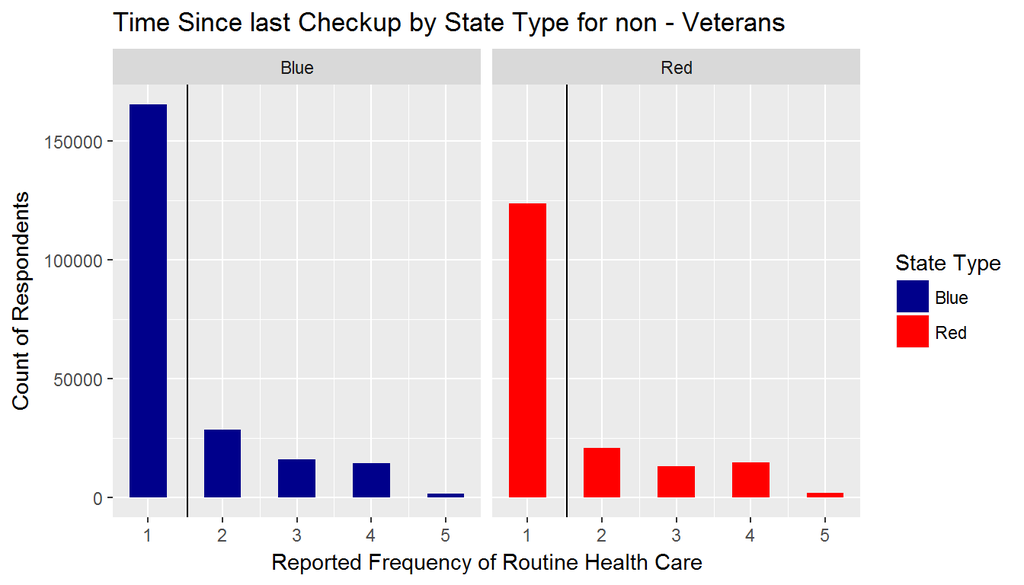

```r
# Question 2 data

p3dat<-mydata %>%
  select(checkup1, veteran3, Type) %>%
  filter(veteran3=="No")

p4dat<-mydata %>%
  select(checkup1, veteran3, Type) %>%
  filter(veteran3=="Yes")

# Histogram of non-Veterans

p3<-ggplot(p3dat, aes(checkup1, fill=Type))+geom_histogram(binwidth = .5)+
  facet_grid(.~Type)+scale_fill_manual(values=c("#00008b", "#ff0000"))+
  geom_vline(xintercept=mean(p3dat$checkup1), color="black")+
  ggtitle("Time Since last Checkup by State Type for non - Veterans")+
  guides(fill=guide_legend(title="State Type"))+
  ylab("Count of Respondents") + xlab("Reported Frequency of Routine Health Care")


p3
```

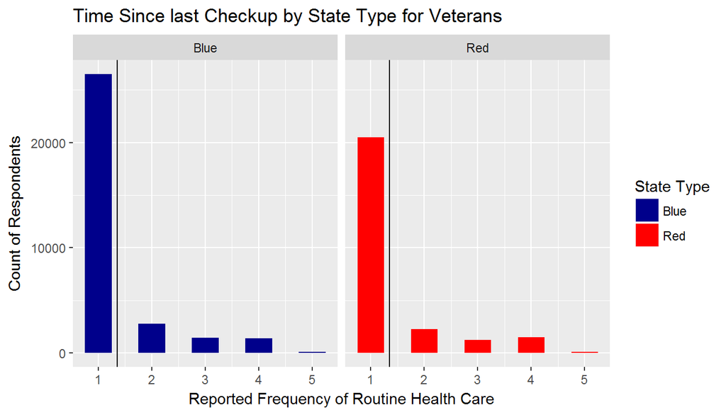

```r
# Histogram of veterans

p4<-ggplot(p4dat, aes(checkup1, fill=Type))+geom_histogram(binwidth = .5)+
  facet_grid(.~Type)+scale_fill_manual(values=c("#00008b", "#ff0000"))+
  geom_vline(xintercept = mean(p4dat$checkup1), color="black")+
  ggtitle("Time Since last Checkup by State Type for Veterans")+
  guides(fill=guide_legend(title="State Type"))+
  ylab("Count of Respondents") + xlab("Reported Frequency of Routine Health Care")


p4
```

**Research quesion 3:**

Is being a veteran and smoking more than 100 cigarettes associated with being diagnosed with a heart attack?

Here is a table of the heart attack rates of veteran and non-veteran smokers and non-smokers:

```r
sum3<- mydata %>%
  select(cvdinfr4, veteran3, smoke100) %>%
  group_by(veteran3, smoke100, cvdinfr4) %>%
  summarise(Sum=n()) %>%
  spread(cvdinfr4, Sum) %>%
  mutate(Sum = Yes+No, `PctYes` = round(Yes/Sum*100, digits =1))

head(sum3)
```

```
## # A tibble: 4 x 6
## # Groups:   veteran3, smoke100 [4]
##   veteran3 smoke100   Yes     No    Sum PctYes
##     <fctr>   <fctr> <int>  <int>  <int>  <dbl>
## 1      Yes      Yes  5717  30800  36517   15.7
## 2      Yes       No  1833  19674  21507    8.5
## 3       No      Yes 12053 159347 171400    7.0
## 4       No       No  7798 221597 229395    3.4
```

The data show a positive association between being a veteran and being diagnosed with a heart attach for both smokers and non-smokers. As shown in the chart below, non-smoking veterans report being diagnosed with heart attacks at a higher rate than smokers who are not veterans.

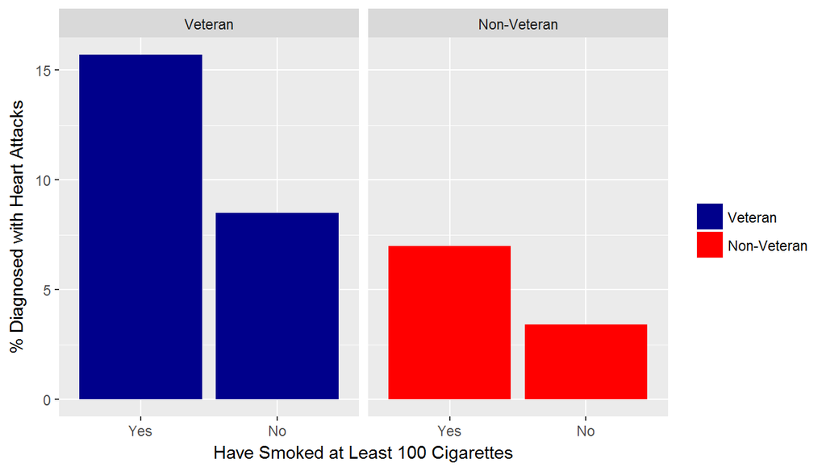

```r
levels(sum3$veteran3)<-c("Veteran", "Non-Veteran")
p5<-ggplot(sum3, aes(smoke100))+
  geom_bar(aes(weight=PctYes, fill=veteran3))+
  facet_grid(.~veteran3)+scale_fill_manual(values=c("#00008b", "#ff0000"))+
  ylab("% Diagnosed with Heart Attacks")+xlab("Have Smoked at Least 100 Cigarettes")+
  guides(fill=guide_legend(title=NULL))

p5
```

**Summary**

We find with our first question a positive association between reported general health and being a veteran. There also is a positive association between living in a red state and better reported general health.

With the second question, we find a positive association between living in a blue state and more frequent routine health care. We also find a positive association between being a veteran and more frequent routine health care.

The results of the first two questions are intriguing. Residents of blue states report lower general health;, but more frequent routine health care. Do they go to the doctor more often because of poor health? Or, does more frequent care diagnose more issues, which in turn might be associated with lower reported health scores?

The third question shows a positive association with being a veteran and being diagnosed with a heart attack. Non-smoking veterans actually reported being diagnosed with a heart attack more often than smoking non-veterans. There is also a clear positive association with being diagnosed with a heart attack and being a smoker.

**Code**

All of the code developed for this analysis can be accessed at this link: [https://github.com/lecroc/Introduction-to-Probability]